title: “Atividade prática 3 - Modelagem Estatística” date: “2026-10-07” output: html_document ———————

# Parte 1 – Tempo de atendimento de uma plataforma

## Carregando os dados da amostra

```r
tempo <- c(
  11.4, 12.8, 13.1, 11.7, 12.5,
  13.4, 12.9, 11.8, 12.6, 13.0,
  12.2, 13.3, 11.9, 12.7, 13.5,
  12.4, 12.8, 13.1, 12.0, 12.9
)
```

## 1. Conhecendo os dados

```r
length(tempo)
```

```
## [1] 20
```

```r
mean(tempo)
```

```
## [1] 12.6
```

```r
sd(tempo)
```

```
## [1] 0.5991222
```

```r
summary(tempo)
```

```
##    Min. 1st Qu.  Median    Mean 3rd Qu.    Max.
##   11.40   12.15   12.75   12.60   13.03   13.50
```

### a) Qual é o tamanho da amostra?

**Resposta:** 20.

### c) Qual é o desvio padrão amostral?

**Resposta:** 0,5991222.

### d) A média observada parece próxima de 12 minutos? Comente brevemente.

**Resposta:** A média é superior a 12 minutos.

## 2. Visualização dos dados

**Resposta:** Os dados aparentam ter uma distribuição razoavelmente simétrica e sem outliers.

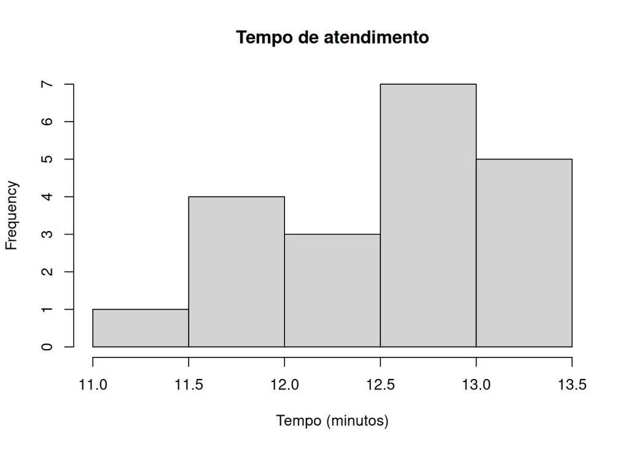

```r
hist(
  tempo,
  main = "Tempo de atendimento",
  xlab = "Tempo (minutos)"
)
```

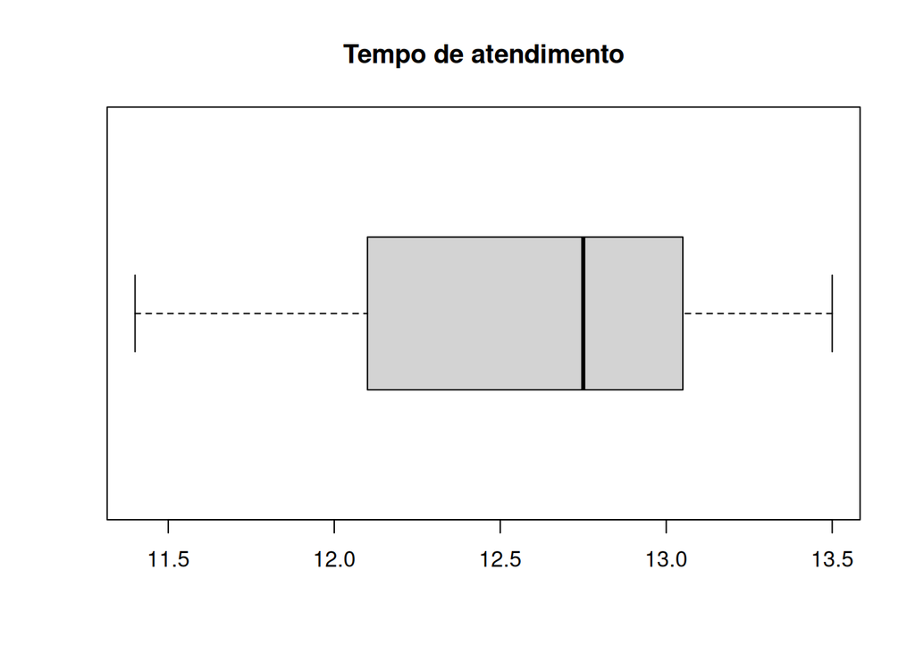

```r
boxplot(
  tempo,
  horizontal = TRUE,
  main = "Tempo de atendimento"
)
```

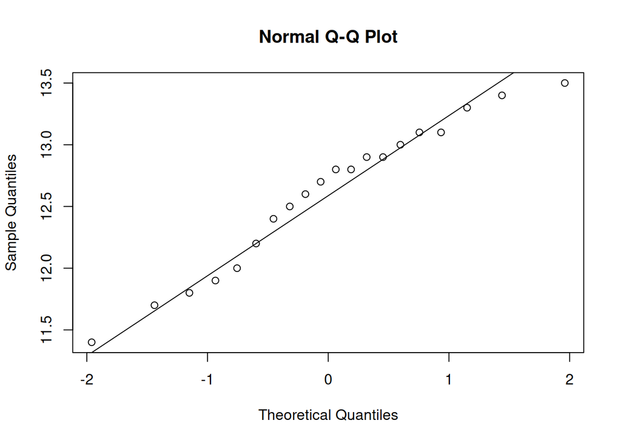

```r
qqnorm(tempo)

qqline(tempo)
```

# Parte 2 – Formulação do teste

## 3. Parâmetro de interesse

**Resposta:** $\mu$ = Tempo médio populacional de atendimento dos chamados na plataforma.

## 4. Hipóteses estatísticas

**Resposta:**

$$H_0: \mu = 12$$

$$H_1: \mu \neq 12$$

## 5. Tipo de teste

**Resposta:** Bilateral.

# Parte 3 – Realizando o teste no R

```r
resultado <- t.test(
  tempo,
  mu = 12,
  alternative = "two.sided",
  conf.level = 0.95
)

resultado
```

```
##
##  One Sample t-test
##
## data:  tempo
## t = 4.4787, df = 19, p-value = 0.0002573
## alternative hypothesis: true mean is not equal to 12
## 95 percent confidence interval:
##  12.3196 12.8804
## sample estimates:
## mean of x
##      12.6
```

## 6. Identificação dos resultados

# Parte 4 – Tomando a decisão

## 8. Conclusão contextual

**Resposta:** É possível concluir que o tempo médio é diferente de 12 minutos.

# Parte 5 – Relação entre teste e intervalo de confiança

## 9. O valor 12 pertence ao intervalo de confiança de 95%?

**Resposta:** Não.

## 10. O resultado do intervalo é coerente com a decisão do teste?

**Resposta:** É coerente, pois o valor 12 não é um candidato plausível para a média populacional sob 95% de confiança.

# Parte 6 – Mudando a pergunta de pesquisa

## 11. Formule as novas hipóteses

**Resposta:**

$$H_0: \mu = 12$$

$$H_1: \mu > 12$$

## 12. Execute o teste unilateral

```r
t.test(
  tempo,
  mu = 12,
  alternative = "greater"
)
```

```
##
##  One Sample t-test
##
## data:  tempo
## t = 4.4787, df = 19, p-value = 0.0001287
## alternative hypothesis: true mean is greater than 12
## 95 percent confidence interval:
##  12.36835      Inf
## sample estimates:
## mean of x
##      12.6
```

## 13. Compare os dois testes

**Resposta:** O p-valor do teste unilateral é a metade do p-valor do teste bilateral.

# Parte 7 – Teste para uma proporção

```r
n <- 120

sucessos <- 64

phat <- sucessos / n

phat
```

```
## [1] 0.5333333
```

## 14. Proporção observada

**Resposta:** $\hat{p} = 0,5333$ (ou 53,33%).

## 15. Formulação das hipóteses

**Resposta:**

$$H_0: p = 0,60$$

$$H_1: p < 0,60$$

(Teste unilateral à esquerda).

## 16. Execute o teste no R

```r
prop.test(
  x = sucessos,
  n = n,
  p = 0.60,
  alternative = "less",
  correct = FALSE
)
```

```
##
##  1-sample proportions test without continuity correction
##
## data:  sucessos out of n, null probability 0.6
## X-squared = 2.2222, df = 1, p-value = 0.06802
## alternative hypothesis: true p is less than 0.6
## 95 percent confidence interval:
##  0.0000000 0.6066815
## sample estimates:
##         p
## 0.5333333
```

## 17. Conclusão contextual

**Resposta:** Não é possível afirmar estatisticamente que a taxa verdadeira de usuários que concluem o cadastro é menor que 60%.

# Desafio final – A fronteira de 5% p-valor

## 18. Discussão

**Resposta:** Não. Na prática, a força de evidência de ambos é quase idêntica.